# Regularización y CV con salarios de la NBA

Iker Aguirre Otaegui

07/11/2020

### Objetivo del trabajo.

El objetivo de este trabajo es usar, entre otras, distintas métricas sobre el rendimiento de jugadores de la NBA con las que elaborar un modelo para predecir su posible salario. Se utilizarán las técnicas de cross validation y regularización para seleccionar el mejor modelo desde un punto de vista predictivo.

## 1. Carga de librerías.

```r
library(here)
library(tidyverse)
library(janitor)
library(skimr)
library(magrittr)
```

```r
library(corrplot)
library(ggcorrplot)
library(PerformanceAnalytics)
library(leaps)
library(rsample)
library(glmnet)
library(dplyr)
```

## 2. Carga del dataset.

```r
nba_raw <- read.csv("nba.csv")
colnames(nba_raw)
```

```
##  [1] "Player"          "Salary"          "NBA_Country"     "NBA_DraftNumber"
##  [5] "Age"             "Tm"              "G"               "MP"
##  [9] "PER"             "TS."             "X3PAr"           "FTr"
## [13] "ORB."            "DRB."            "TRB."            "AST."
## [17] "STL."            "BLK."            "TOV."            "USG."
## [21] "OWS"             "DWS"             "WS"              "WS.48"
## [25] "OBPM"            "DBPM"            "BPM"             "VORP"
```

## 3. Exploración de datos raw.

```r
str(nba_raw)
```

```
## 'data.frame':    485 obs. of  28 variables:
##  $ Player         : chr  "Zhou Qi" "Zaza Pachulia" "Zach Randolph" "Zach LaVine" ...
##  $ Salary         : int  815615 3477600 12307692 3202217 3057240 1312611 74159 46080 12016854 1435750 ...
##  $ NBA_Country    : chr  "China" "Georgia" "USA" "USA" ...
##  $ NBA_DraftNumber: int  43 42 19 13 10 62 62 62 23 35 ...
##  $ Age            : int  22 33 36 22 20 24 30 23 30 23 ...
##  $ Tm             : chr  "HOU" "GSW" "SAC" "CHI" ...
##  $ G              : int  16 66 59 24 62 79 2 5 70 45 ...
##  $ MP             : int  87 937 1508 656 979 2238 7 118 2200 430 ...
##  $ PER            : num  0.6 16.8 17.3 14.6 8.2 11.5 -4.9 0.9 11.1 20.6 ...
##  $ TS.            : num  0.303 0.608 0.529 0.499 0.487 0.543 0 0.315 0.543 0.592 ...
##  $ X3PAr          : num  0.593 0.004 0.193 0.346 0.387 0.489 0.667 0.333 0.39 0.075 ...
##  $ FTr            : num  0.37 0.337 0.14 0.301 0.146 0.141 0 0.214 0.186 0.555 ...
##  $ ORB.           : num  6.5 11 7 1.4 4.9 1.3 15.9 0 5 13.6 ...
##  $ DRB.           : num  16.8 25 23.8 14.4 18.3 11.3 15.4 5 14 25.2 ...
##  $ TRB.           : num  11.7 18.5 15 7.7 11.7 6.1 15.7 2.5 9.5 19.3 ...
##  $ AST.           : num  1.5 15.4 14.9 18.6 7.3 13.3 0 23.2 9.7 11 ...
##  $ STL.           : num  1.1 1.9 1.4 1.8 0.8 1.4 7.2 2.6 0.9 1.8 ...
##  $ BLK.           : num  6.8 1.3 0.6 0.5 2.5 0.3 0 2.4 1.4 2.8 ...
##  $ TOV.           : num  18.2 19.3 12.5 9.7 15.6 9.1 0 19.3 12 15.4 ...
##  $ USG.           : num  19.5 17.2 27.6 29.5 15.5 17 19.2 21.7 14.6 21.7 ...
##  $ OWS            : num  -0.4 1.7 0.3 -0.1 -0.4 1.6 -0.1 -0.5 2 0.8 ...
##  $ DWS            : num  0.1 1.4 1.1 0.5 1.2 1.6 0 0.1 1 0.6 ...
##  $ WS             : num  -0.2 3.1 1.4 0.4 0.8 3.1 0 -0.4 3.1 1.4 ...
##  $ WS.48          : num  -0.121 0.16 0.046 0.027 0.038 0.067 -0.251 -0.169 0.067 0.156 ...
##  $ OBPM           : num  -10.6 -0.6 -0.6 -0.7 -3.7 -0.4 -12.6 -8.7 -0.4 -0.1 ...
##  $ DBPM           : num  0.5 1.3 -1.3 -2 0.9 -0.5 -0.7 -1.9 -0.6 0.6 ...
##  $ BPM            : num  -10.1 0.8 -1.9 -2.6 -2.9 -0.9 -13.3 -10.6 -1 0.5 ...
##  $ VORP           : num  -0.2 0.7 0 -0.1 -0.2 0.6 0 -0.3 0.5 0.3 ...
```

```r
head(nba_raw)
```

```
##          Player   Salary NBA_Country NBA_DraftNumber Age  Tm  G   MP  PER   TS.
## 1       Zhou Qi   815615       China              43  22 HOU 16   87  0.6 0.303
## 2 Zaza Pachulia  3477600     Georgia              42  33 GSW 66  937 16.8 0.608
## 3 Zach Randolph 12307692         USA              19  36 SAC 59 1508 17.3 0.529
## 4   Zach LaVine  3202217         USA              13  22 CHI 24  656 14.6 0.499
## 5  Zach Collins  3057240         USA              10  20 POR 62  979  8.2 0.487
## 6  Yogi Ferrell  1312611         USA              62  24 DAL 79 2238 11.5 0.543
##   X3PAr   FTr ORB. DRB. TRB. AST. STL. BLK. TOV. USG.  OWS DWS   WS  WS.48
## 1 0.593 0.370  6.5 16.8 11.7  1.5  1.1  6.8 18.2 19.5 -0.4 0.1 -0.2 -0.121
## 2 0.004 0.337 11.0 25.0 18.5 15.4  1.9  1.3 19.3 17.2  1.7 1.4  3.1  0.160
## 3 0.193 0.140  7.0 23.8 15.0 14.9  1.4  0.6 12.5 27.6  0.3 1.1  1.4  0.046
## 4 0.346 0.301  1.4 14.4  7.7 18.6  1.8  0.5  9.7 29.5 -0.1 0.5  0.4  0.027
## 5 0.387 0.146  4.9 18.3 11.7  7.3  0.8  2.5 15.6 15.5 -0.4 1.2  0.8  0.038
## 6 0.489 0.141  1.3 11.3  6.1 13.3  1.4  0.3  9.1 17.0  1.6 1.6  3.1  0.067
##    OBPM DBPM   BPM VORP
## 1 -10.6  0.5 -10.1 -0.2
## 2  -0.6  1.3   0.8  0.7
## 3  -0.6 -1.3  -1.9  0.0
## 4  -0.7 -2.0  -2.6 -0.1
## 5  -3.7  0.9  -2.9 -0.2
## 6  -0.4 -0.5  -0.9  0.6
```

```r
skim(nba_raw)
```

Data summary

| Name | nba_raw |
| --- | --- |
| Number of rows | 485 |
| Number of columns | 28 |
| _______________________ |  |
| Column type frequency: |  |
| character | 3 |
| numeric | 25 |
| ________________________ |  |
| Group variables | None |

**Variable type: character**

| skim_variable | n_missing | complete_rate | min | max | empty | n_unique | whitespace |
| --- | --- | --- | --- | --- | --- | --- | --- |
| Player | 0 | 1 | 7 | 24 | 0 | 483 | 0 |
| NBA_Country | 0 | 1 | 3 | 16 | 0 | 44 | 0 |
| Tm | 0 | 1 | 3 | 3 | 0 | 31 | 0 |

**Variable type: numeric**

| skim_variable | n_missing | complete_rate | mean | sd | p0 | p25 | p50 | p75 | p100 | hist |
| --- | --- | --- | --- | --- | --- | --- | --- | --- | --- | --- |
| Salary | 0 | 1 | 6636507.50 | 7392601.91 | 46080.00 | 1471382.00 | 3202217.00 | 1.000e+07 | 34682550.00 | ▇▂▁▁▁ |
| NBA_DraftNumber | 0 | 1 | 29.45 | 21.13 | 1.00 | 11.00 | 25.00 | 4.700e+01 | 62.00 | ▇▆▃▃▆ |
| Age | 0 | 1 | 26.26 | 4.27 | 19.00 | 23.00 | 26.00 | 2.900e+01 | 41.00 | ▇▇▆▂▁ |
| G | 0 | 1 | 50.17 | 24.87 | 1.00 | 29.00 | 59.00 | 7.100e+01 | 79.00 | ▃▂▂▃▇ |
| MP | 0 | 1 | 1154.14 | 811.36 | 1.00 | 381.00 | 1134.00 | 1.819e+03 | 2898.00 | ▇▅▆▅▂ |
| PER | 0 | 1 | 13.26 | 8.77 | -41.10 | 9.80 | 13.20 | 1.650e+01 | 134.10 | ▁▇▁▁▁ |
| TS. | 2 | 1 | 0.54 | 0.11 | 0.00 | 0.51 | 0.54 | 5.800e-01 | 1.50 | ▁▇▂▁▁ |
| X3PAr | 2 | 1 | 0.34 | 0.23 | 0.00 | 0.17 | 0.35 | 4.800e-01 | 1.00 | ▇▇▇▂▁ |
| FTr | 2 | 1 | 0.26 | 0.29 | 0.00 | 0.16 | 0.23 | 3.200e-01 | 5.33 | ▇▁▁▁▁ |
| ORB. | 0 | 1 | 4.87 | 4.58 | 0.00 | 1.80 | 3.20 | 7.000e+00 | 35.90 | ▇▂▁▁▁ |
| DRB. | 0 | 1 | 14.95 | 6.85 | 0.00 | 10.20 | 14.00 | 1.880e+01 | 37.60 | ▂▇▅▂▁ |
| TRB. | 0 | 1 | 9.91 | 4.96 | 0.00 | 6.20 | 8.70 | 1.330e+01 | 26.50 | ▂▇▃▂▁ |
| AST. | 0 | 1 | 12.95 | 9.11 | 0.00 | 6.90 | 9.90 | 1.760e+01 | 49.40 | ▇▅▂▁▁ |
| STL. | 0 | 1 | 1.53 | 0.99 | 0.00 | 1.00 | 1.50 | 1.900e+00 | 12.50 | ▇▁▁▁▁ |
| BLK. | 0 | 1 | 1.71 | 1.68 | 0.00 | 0.60 | 1.20 | 2.200e+00 | 13.40 | ▇▂▁▁▁ |
| TOV. | 2 | 1 | 13.14 | 6.12 | 0.00 | 9.90 | 12.50 | 1.575e+01 | 66.70 | ▇▆▁▁▁ |
| USG. | 0 | 1 | 18.90 | 5.94 | 0.00 | 15.00 | 17.90 | 2.220e+01 | 45.10 | ▁▇▆▁▁ |
| OWS | 0 | 1 | 1.28 | 1.88 | -2.30 | 0.00 | 0.80 | 2.000e+00 | 11.40 | ▇▇▂▁▁ |
| DWS | 0 | 1 | 1.18 | 1.03 | 0.00 | 0.30 | 1.00 | 1.800e+00 | 5.60 | ▇▅▂▁▁ |
| WS | 0 | 1 | 2.46 | 2.67 | -1.20 | 0.30 | 1.80 | 3.600e+00 | 15.00 | ▇▅▁▁▁ |
| WS.48 | 0 | 1 | 0.08 | 0.16 | -1.06 | 0.04 | 0.08 | 1.200e-01 | 2.71 | ▁▇▁▁▁ |
| OBPM | 0 | 1 | -1.27 | 5.03 | -36.50 | -2.70 | -1.10 | 4.000e-01 | 68.70 | ▁▇▁▁▁ |
| DBPM | 0 | 1 | -0.49 | 2.39 | -14.30 | -1.70 | -0.40 | 1.000e+00 | 6.80 | ▁▁▃▇▁ |
| BPM | 0 | 1 | -1.76 | 5.66 | -49.20 | -3.60 | -1.30 | 5.000e-01 | 54.40 | ▁▁▇▁▁ |
| VORP | 0 | 1 | 0.60 | 1.25 | -1.30 | -0.10 | 0.10 | 9.000e-01 | 8.60 | ▇▃▁▁▁ |

## 4. Limpieza de los datos.

Habiendo visto la composición de los datos en el dataset, realizo varias modificaciones que considero adecuadas para posteriores análisis. Entre ellos:

1. Omisión de valores NA
2. Rescribir el nombre variables a un formato adecuado
3. Elimino las variables “Player” y “Tm”.
4. Modifico la variable “Country”. Puesto que lo que realmente me interesa es si el jugador es estadounidense o internacional, le doy valores 1 a todas las observaciones que correspondan a jugadores americanos, y 0 al resto.

```r
nba <- drop_na(nba_raw)
nba %<>% clean_names()
```

```r
nba$player = NULL
nba$tm = NULL
```

```r
nba$nba_country[nba$nba_country != "USA"] <- 0
nba$nba_country[nba$nba_country == "USA"] <- 1
```

```r
str(nba)
```

```
## 'data.frame':    483 obs. of  26 variables:
##  $ salary          : int  815615 3477600 12307692 3202217 3057240 1312611 74159 46080 12016854 1435750 ...
##  $ nba_country     : chr  "0" "0" "1" "1" ...
##  $ nba_draft_number: int  43 42 19 13 10 62 62 62 23 35 ...
##  $ age             : int  22 33 36 22 20 24 30 23 30 23 ...
##  $ g               : int  16 66 59 24 62 79 2 5 70 45 ...
##  $ mp              : int  87 937 1508 656 979 2238 7 118 2200 430 ...
##  $ per             : num  0.6 16.8 17.3 14.6 8.2 11.5 -4.9 0.9 11.1 20.6 ...
##  $ ts              : num  0.303 0.608 0.529 0.499 0.487 0.543 0 0.315 0.543 0.592 ...
##  $ x3p_ar          : num  0.593 0.004 0.193 0.346 0.387 0.489 0.667 0.333 0.39 0.075 ...
##  $ f_tr            : num  0.37 0.337 0.14 0.301 0.146 0.141 0 0.214 0.186 0.555 ...
##  $ orb             : num  6.5 11 7 1.4 4.9 1.3 15.9 0 5 13.6 ...
##  $ drb             : num  16.8 25 23.8 14.4 18.3 11.3 15.4 5 14 25.2 ...
##  $ trb             : num  11.7 18.5 15 7.7 11.7 6.1 15.7 2.5 9.5 19.3 ...
##  $ ast             : num  1.5 15.4 14.9 18.6 7.3 13.3 0 23.2 9.7 11 ...
##  $ stl             : num  1.1 1.9 1.4 1.8 0.8 1.4 7.2 2.6 0.9 1.8 ...
##  $ blk             : num  6.8 1.3 0.6 0.5 2.5 0.3 0 2.4 1.4 2.8 ...
##  $ tov             : num  18.2 19.3 12.5 9.7 15.6 9.1 0 19.3 12 15.4 ...
##  $ usg             : num  19.5 17.2 27.6 29.5 15.5 17 19.2 21.7 14.6 21.7 ...
##  $ ows             : num  -0.4 1.7 0.3 -0.1 -0.4 1.6 -0.1 -0.5 2 0.8 ...
##  $ dws             : num  0.1 1.4 1.1 0.5 1.2 1.6 0 0.1 1 0.6 ...
##  $ ws              : num  -0.2 3.1 1.4 0.4 0.8 3.1 0 -0.4 3.1 1.4 ...
##  $ ws_48           : num  -0.121 0.16 0.046 0.027 0.038 0.067 -0.251 -0.169 0.067 0.156 ...
##  $ obpm            : num  -10.6 -0.6 -0.6 -0.7 -3.7 -0.4 -12.6 -8.7 -0.4 -0.1 ...
##  $ dbpm            : num  0.5 1.3 -1.3 -2 0.9 -0.5 -0.7 -1.9 -0.6 0.6 ...
##  $ bpm             : num  -10.1 0.8 -1.9 -2.6 -2.9 -0.9 -13.3 -10.6 -1 0.5 ...
##  $ vorp            : num  -0.2 0.7 0 -0.1 -0.2 0.6 0 -0.3 0.5 0.3 ...
```

```r
head(nba)
```

```
##     salary nba_country nba_draft_number age  g   mp  per    ts x3p_ar  f_tr
## 1   815615           0               43  22 16   87  0.6 0.303  0.593 0.370
## 2  3477600           0               42  33 66  937 16.8 0.608  0.004 0.337
## 3 12307692           1               19  36 59 1508 17.3 0.529  0.193 0.140
## 4  3202217           1               13  22 24  656 14.6 0.499  0.346 0.301
## 5  3057240           1               10  20 62  979  8.2 0.487  0.387 0.146
## 6  1312611           1               62  24 79 2238 11.5 0.543  0.489 0.141
##    orb  drb  trb  ast stl blk  tov  usg  ows dws   ws  ws_48  obpm dbpm   bpm
## 1  6.5 16.8 11.7  1.5 1.1 6.8 18.2 19.5 -0.4 0.1 -0.2 -0.121 -10.6  0.5 -10.1
## 2 11.0 25.0 18.5 15.4 1.9 1.3 19.3 17.2  1.7 1.4  3.1  0.160  -0.6  1.3   0.8
## 3  7.0 23.8 15.0 14.9 1.4 0.6 12.5 27.6  0.3 1.1  1.4  0.046  -0.6 -1.3  -1.9
## 4  1.4 14.4  7.7 18.6 1.8 0.5  9.7 29.5 -0.1 0.5  0.4  0.027  -0.7 -2.0  -2.6
## 5  4.9 18.3 11.7  7.3 0.8 2.5 15.6 15.5 -0.4 1.2  0.8  0.038  -3.7  0.9  -2.9
## 6  1.3 11.3  6.1 13.3 1.4 0.3  9.1 17.0  1.6 1.6  3.1  0.067  -0.4 -0.5  -0.9
##   vorp
## 1 -0.2
## 2  0.7
## 3  0.0
## 4 -0.1
## 5 -0.2
## 6  0.6
```

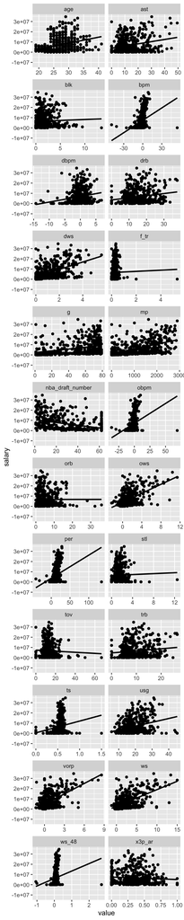

```r
nba %>%
  select_at(vars(-c(nba_country))) %>%
  tidyr::gather("id", "value", 2:25) %>%
  ggplot(., aes(y = salary, x = value)) +
  geom_point() +
  geom_smooth(method = "lm", se=FALSE, color = "black") +
  facet_wrap(~id,ncol = 2,scales = "free_x")
```

## 5. Log.

Pasamos la variable “salary” a logaritmo.

```r
log_nba <- nba %>%
  mutate(salary=log(salary))
```

## 6. Training and test sets.

Creamos dos subsets de la muestra: Uno de entrenamiento (80%) y otro de test (20%).

```r
set.seed(813)
train <- sample(nrow(log_nba), 0.8*nrow(log_nba), replace = FALSE )
nba_train <- log_nba[train,]
nba_test <- log_nba[-train,]
dim(nba_train)
```

```
## [1] 386  26
```

```r
dim(nba_test)
```

```
## [1] 97 26
```

```r
nba_train_x <- model.matrix(salary ~ ., nba_train)[, -1]
nba_train_y <- log(nba_train$salary)

nba_test_x <- model.matrix(salary ~ ., nba_test)[, -1]
nba_test_y <- log(nba_test$salary)
```

## 7. Elastic Net.

Representamos la regularizaciónes Lasso y de Cresta, además de otras de fuerza más intermedia (alpha = 0.25 y 0.75).

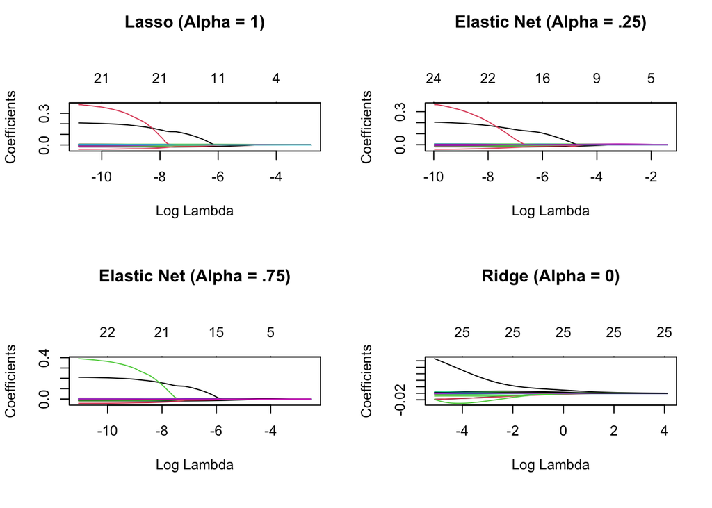

```r
Elastic_net <- function(nba_train_x, nba_train_y){
  lasso <- glmnet(nba_train_x, nba_train_y, alpha = 1.0)
  elastic1 <- glmnet(nba_train_x, nba_train_y, alpha = 0.25)
  elastic2 <- glmnet(nba_train_x, nba_train_y, alpha = 0.75)
  ridge <- glmnet(nba_train_x, nba_train_y, alpha = 0.0)
  par(mfrow = c(2, 2), mar = c(6, 4, 6, 2) + 0.1)
  plot(lasso, xvar = "lambda", main = "Lasso (Alpha = 1)\n\n\n")
  plot(elastic1, xvar = "lambda", main = "Elastic Net (Alpha = .25)\n\n\n")
  plot(elastic2, xvar = "lambda", main = "Elastic Net (Alpha = .75)\n\n\n")
  plot(ridge, xvar = "lambda", main = "Ridge (Alpha = 0)\n\n\n")
}
Elastic_net(nba_train_x, nba_train_y)
```

Hallamos las alphas mediante cross validation.

```r
fold_id <- sample(1:10, size = length(nba_train_y), replace=TRUE)

tuning_grid <- tibble::tibble(
  alpha = seq(0, 1, by = .1),
  mse_min = NA,
  mse_1se = NA,
  lambda_min = NA,
  lambda_1se = NA
)

for(i in seq_along(tuning_grid$alpha)) {
  fit <- cv.glmnet(nba_train_x, nba_train_y, alpha = tuning_grid$alpha[i], foldid = fold_id)
  tuning_grid$mse_min[i] <- fit$cvm[fit$lambda == fit$lambda.min]
  tuning_grid$mse_1se[i] <- fit$cvm[fit$lambda == fit$lambda.1se]
  tuning_grid$lambda_min[i] <- fit$lambda.min
  tuning_grid$lambda_1se[i] <- fit$lambda.1se
}
tuning_grid
```

```
## # A tibble: 11 x 5
##    alpha mse_min mse_1se lambda_min lambda_1se
##    <dbl>   <dbl>   <dbl>      <dbl>      <dbl>
##  1   0   0.00653 0.00720    0.0296      0.158
##  2   0.1 0.00646 0.00719    0.0310      0.104
##  3   0.2 0.00632 0.00694    0.0225      0.0626
##  4   0.3 0.00628 0.00697    0.0150      0.0503
##  5   0.4 0.00626 0.00684    0.0123      0.0377
##  6   0.5 0.00624 0.00690    0.00988     0.0331
##  7   0.6 0.00623 0.00685    0.00904     0.0276
##  8   0.7 0.00622 0.00681    0.00774     0.0237
##  9   0.8 0.00621 0.00693    0.00678     0.0227
## 10   0.9 0.00621 0.00690    0.00602     0.0202
## 11   1   0.00620 0.00686    0.00595     0.0182
```

Calculo el error de Lasso y Cresta.

```r
nba_lasso <- cv.glmnet(nba_train_x, nba_train_y, alpha = 1.0)
min(nba_lasso$cvm)
```

```
## [1] 0.006141326
```

```r
nba_ridge <- cv.glmnet(nba_train_x, nba_train_y, alpha = 0.0)
min(nba_ridge$cvm)
```

```
## [1] 0.006549682
```

Al tener menor error, predecimos por Lasso con el test set.

```r
prediccion <- predict(nba_lasso, s = nba_lasso$lambda.min, nba_test_x)
mean((nba_test_y - prediccion)^2)
```

```
## [1] 0.00423441
```